# Case Study 6: The Collapse of Construction in Idaho

- Show All Code
- Hide All Code
- View Source

Author

Austin Mangelson

## Background

In working with the Idaho Restaurant Commission (IRC), we’re setting out to get a clearer picture of how restaurant construction changed across Idaho **from 2008 to 2009**.

The data for this project, found [here](https://github.com/hathawayj/buildings), contains information on buildings built in Idaho during ’08 and ’09, information about each county, residential permits, and more.

## Exploring Questions for the ID Restaurant Commission

Throughout this report we will be answering 4 questions for our IRC friends:

1. *How did full-service restaurant construction compare to quick service restaurant construction across county and years?*
2. *How did restaurant construction fare compare to the other commercial construction in Idaho?*
3. *Which county in Idaho spent the most on fast food construction each year?*
4. *In that county how did other commercial construction compare?*

Let’s jump in!

### Question 1: How did full-service restaurant construction compare to quick service restaurant construction across county and years?

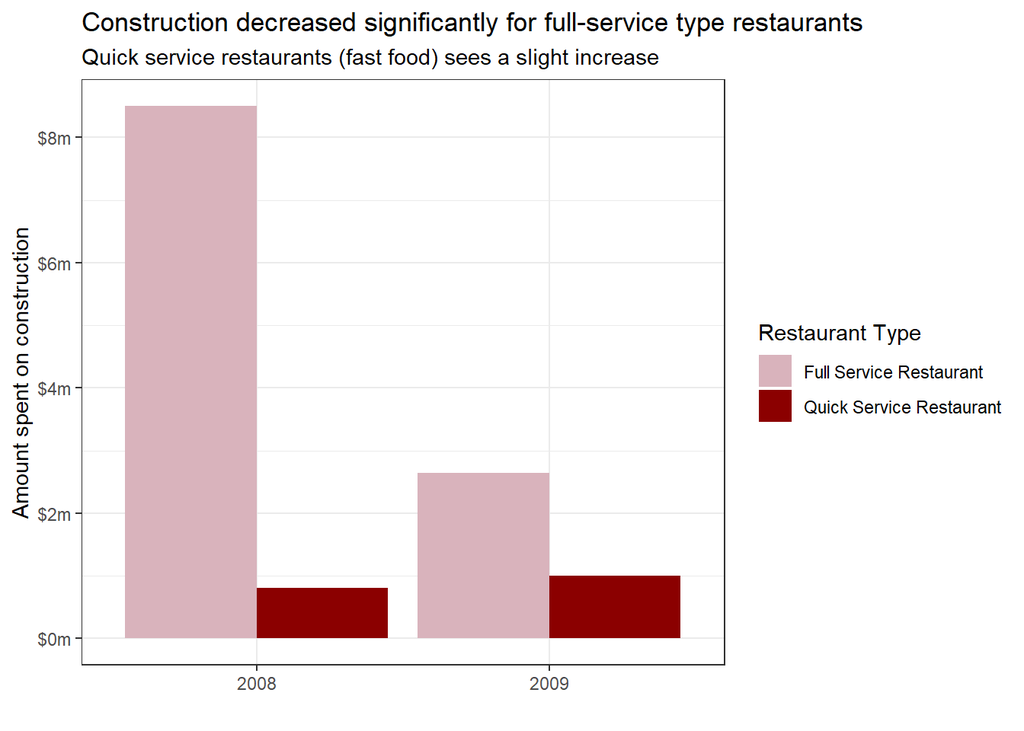

```r
buildings2 |>
  filter(category %in% c("Full Service Restaurant", "Quick Service Restaurant")) |>
  group_by(county, Year, category) |>
  summarise(building_value = sum(value_million, na.rm = TRUE)) |>
  ggplot(buildings2, mapping = aes(x = Year, y = building_value, fill = category)) +
  geom_bar(stat = "identity", position = "dodge") +
  scale_y_continuous(labels = label_dollar(prefix = "$", suffix = "m")) +
  theme_bw() +
  scale_fill_manual(values=c("#D9B3BC", "darkred")) +
  labs(
    title = "Construction decreased significantly for full-service type restaurants",
    subtitle = "Quick service restaurants (fast food) sees a slight increase",
    x = "",
    y = "Amount spent on construction",
    fill = "Restaurant Type")
```

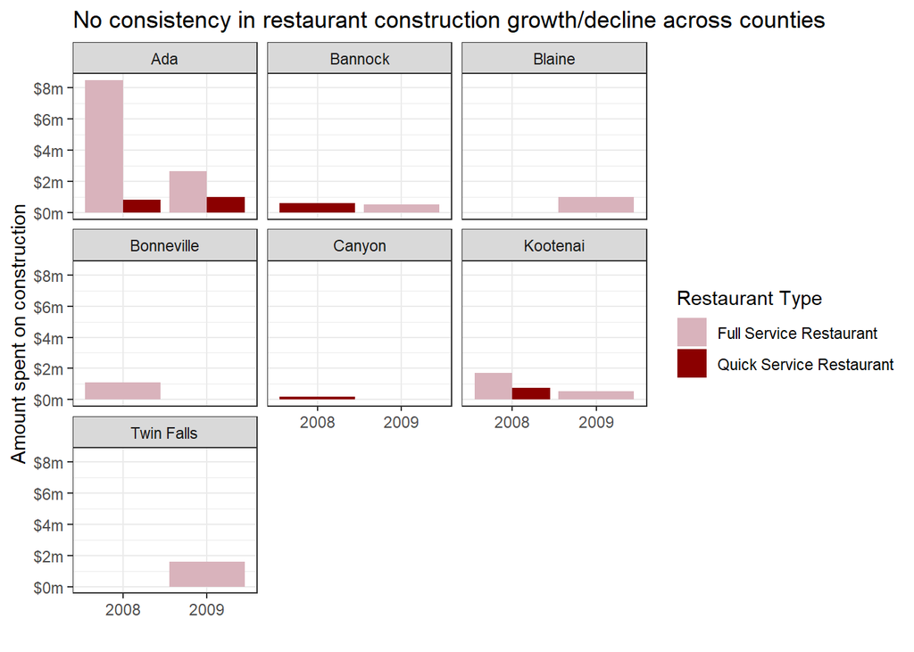

```r
buildings2 |>
  filter(category %in% c("Full Service Restaurant", "Quick Service Restaurant")) |>
  group_by(county, Year, category) |>
  summarise(building_value = sum(value_million, na.rm = TRUE)) |>
  ggplot(buildings2, mapping = aes(x = Year, y = building_value, fill = category)) +
  geom_bar(stat = "identity", position = "dodge") +
  scale_y_continuous(labels = label_dollar(prefix = "$", suffix = "m")) +
  theme_bw() +
  scale_fill_manual(values=c("#D9B3BC", "darkred")) +
  facet_wrap(~county) +
  labs(
    title = "No consistency in restaurant construction growth/decline across counties",
    x = "",
    y = "Amount spent on construction",
    fill = "Restaurant Type")
```

It turns out there is no discernible trend of full or quick service restaurant construction either increasing or decreasing among individual counties.

### Question 2: How did restaurant construction fare compare to the other commercial construction in Idaho?

Before looking at how much money was spend within different construction categories, let’s first see where how many restaurant construction projects there were compared to other projects.

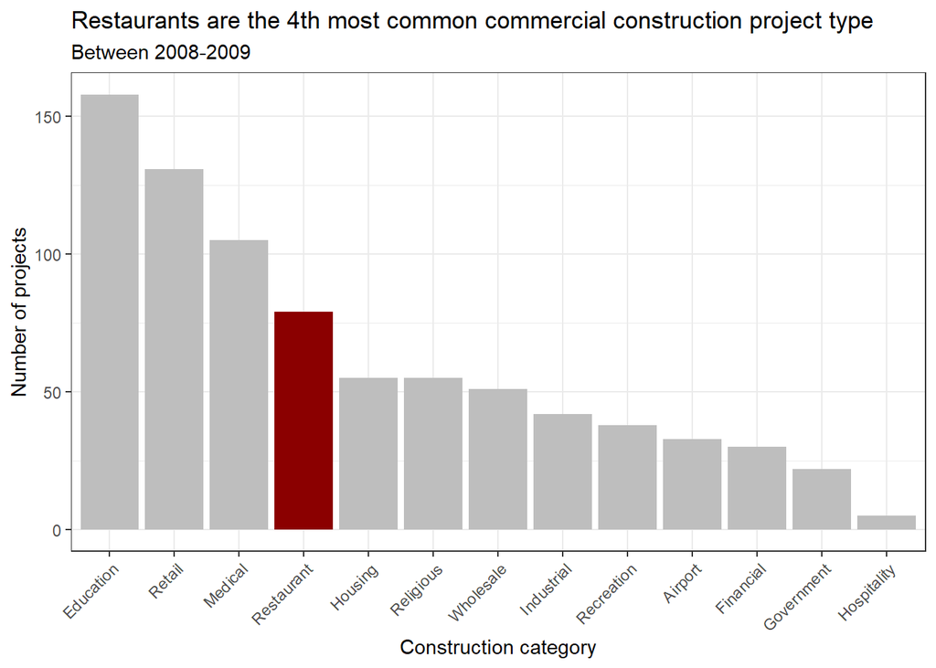

```r
ggplot(commercial_categories, mapping = aes(x = fct_infreq(category), fill = category)) +
  geom_bar() +
  theme_bw() +
  scale_fill_manual(values=c("grey", "grey", "grey", "grey", "grey", "grey", "grey", "grey", "grey", "grey", "darkred", "grey", "grey")) +
  theme(legend.position = "none") +
  theme(axis.text.x = element_text(angle = 45, vjust = 1, hjust = 1)) +
  labs(
    title = "Restaurants are the 4th most common commercial construction project type",
    subtitle = "Between 2008-2009",
    x = "Construction category",
    y = "Number of projects"
  )
```

Now let’s see how the spending on restaurant construction compares to other spending.

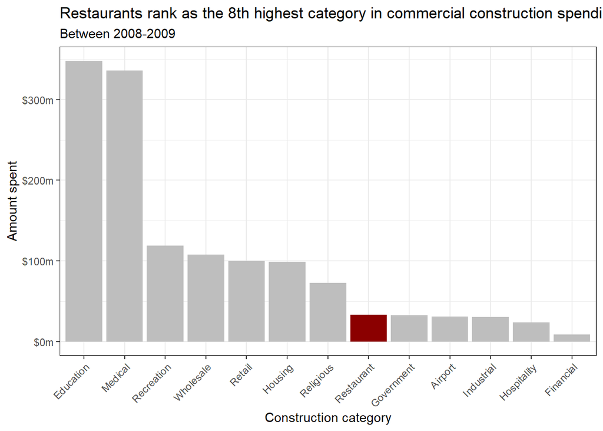

```r
commercial_categories_2 <-
  commercial_categories |>
  group_by(category) |>
  mutate(value_million = (Value1000 / 1000)) |>
  summarise(building_value_mil = sum(value_million, na.rm = TRUE))

ggplot(commercial_categories_2, aes(x = reorder(category, -building_value_mil), y = building_value_mil, fill = category)) +
  geom_bar(stat = "identity") +
  theme_bw() +
  scale_y_continuous(labels = label_dollar(prefix = "$", suffix = "m")) +
  scale_fill_manual(values = c("grey", "grey", "grey", "grey", "grey", "grey", "grey", "grey", "grey", "grey", "darkred", "grey", "grey")) +
  theme(legend.position = "none") +
  theme(axis.text.x = element_text(angle = 45, vjust = 1, hjust = 1)) +
  labs(
    title = "Restaurants rank as the 8th highest category in commercial construction spending",
    subtitle = "Between 2008-2009",
    x = "Construction category",
    y = "Amount spent"
  )
```

Although restaurant construction is the 4th most common commercial construction project type, it falls 8th among amounts of money spent.

Why is this? Although this isn’t the scope of this project, a possible explanation is that while relatively common in number, restaurant construction involves smaller expenditures (perhaps due to smaller footprints or less complex structural requirements) than something like a medical facility or high-rise office would require. Consequently, there restaurants would have shorter planning and construction periods, leading to lower accumulated costs over time.

More research should be done if this is an area of interest for the IRC.

### Question 3: Which county in Idaho spent the most on fast food construction each year?

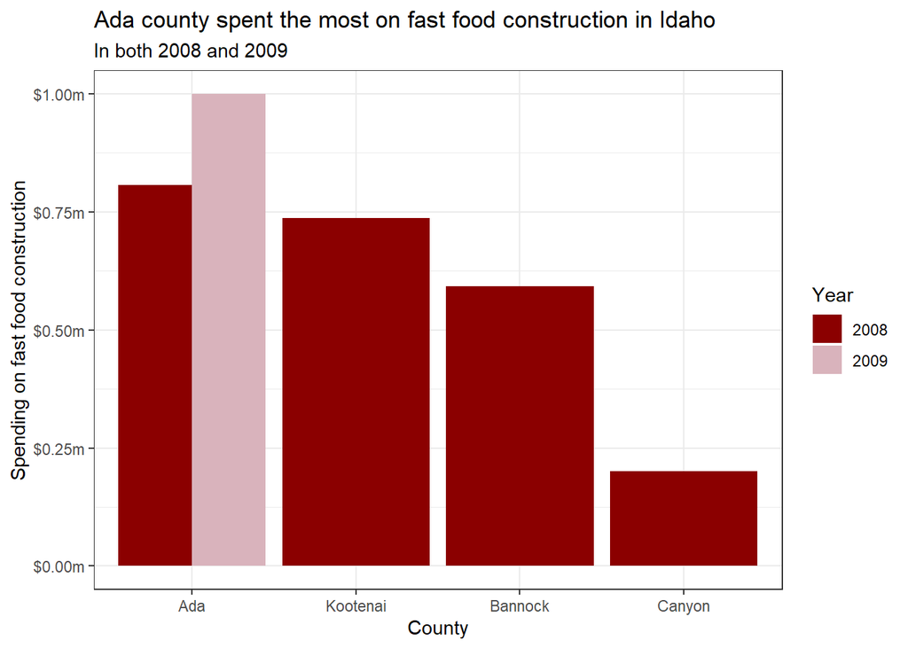

```r
buildings2 |>
  group_by(county, category, Year) |>
  summarise(value_million = sum(value_million, na.rm = TRUE)) |>
  filter(category == "Quick Service Restaurant") |>
  ggplot(buildings2, mapping = aes(x = reorder(county, -value_million), y = value_million, fill = Year)) +
  geom_bar(stat = "identity", position = "dodge") +
  scale_y_continuous(labels = label_dollar(prefix = "$", suffix = "m")) +
  scale_fill_manual(values = c("darkred", "#D9B3BC")) +
  theme_bw() +
  labs(
    title = "Ada county spent the most on fast food construction in Idaho",
    subtitle = "In both 2008 and 2009",
    x = "County",
    y = "Spending on fast food construction"
  )
```

Interestingly, only 4 counties in Idaho spent money on fast food construction. Of those, Ada county spent the most, also being the only county to spend on fast food construction in 2009.

### Question 4: In that county, how did other commercial construction compare?

[figure not shown]

```r
ggplot(commercial_categories_2, aes(x = reorder(category, -building_value_mil), y = building_value_mil, fill = category)) +
  geom_bar(stat = "identity") +
  theme_bw() +
  scale_y_continuous(labels = label_dollar(prefix = "$", suffix = "m")) +
  scale_fill_manual(values = c("grey", "grey", "grey", "grey", "grey", "grey", "grey", "grey", "grey", "grey", "darkred", "grey", "grey")) +
  theme(legend.position = "none") +
  theme(axis.text.x = element_text(angle = 45, vjust = 1, hjust = 1)) +
  labs(
    title = "Restaurant in Ada County, ID remain the 8th highest category in commercial construction spending",
    subtitle = "Between 2008-2009",
    x = "Construction Category",
    y = "Amount spent"
  )
```